# find_tsne_settings_unirep

This notebook is intended to explore the 1.1.3.15 data and figure out the storyline.  
Copyright (C) 2017 Martin Engqvist Lab  
This program is free software: you can redistribute it and/or modify  
it under the terms of the GNU General Public License as published by  
the Free Software Foundation, either version 3 of the License, or  
(at your option) any later version.  
This program is distributed in the hope that it will be useful,  
but WITHOUT ANY WARRANTY; without even the implied warranty of  
MERCHANTABILITY or FITNESS FOR A PARTICULAR PURPOSE. See the  
GNU General Public License for more details.  
You should have received a copy of the GNU General Public License  
along with this program. If not, see http://www.gnu.org/licenses/.

```python
import os
from dotenv import load_dotenv, find_dotenv
from os.path import join, dirname, basename, exists, isdir

### Load environmental variables from the project root directory ###
# find .env automagically by walking up directories until it's found
dotenv_path = find_dotenv()

# load up the entries as environment variables
load_dotenv(dotenv_path)

# now you can get the variables using their names

# Check whether a network drive has been specified
DATABASE = os.environ.get("NETWORK_URL")
if DATABASE == 'None':
    pass
else:
    pass
    #mount network drive here

# set up directory paths
CURRENT_DIR = os.getcwd()
PROJ = dirname(dotenv_path) # project root directory

DATA = join(PROJ, 'data') #data directory
RAW_EXTERNAL = join(DATA, 'raw_external') # external data raw directory
RAW_INTERNAL = join(DATA, 'raw_internal') # internal data raw directory
INTERMEDIATE = join(DATA, 'intermediate') # intermediate data directory
FINAL = join(DATA, 'final') # final data directory

RESULTS = join(PROJ, 'results') # output directory
FIGURES = join(RESULTS, 'figures') # figure output directory
PICTURES = join(RESULTS, 'pictures') # picture output directory


# make folders specific for certain data
folder_name = 'similarity_data'
if folder_name != '':
#     #make folders if they don't exist
#     if not exists(join(RAW_EXTERNAL, folder_name)):
#         os.makedirs(join(RAW_EXTERNAL, folder_name))

#     if not exists(join(INTERMEDIATE, folder_name)):
#         os.makedirs(join(INTERMEDIATE, folder_name))

    if not exists(join(FINAL, folder_name)):
        os.makedirs(join(FINAL, folder_name))

print('Standard variables loaded, you are good to go!')
```

```
Standard variables loaded, you are good to go!
```

```python
import json
import re
import random
import pandas as pd
import numpy as np

import matplotlib.pyplot as plt
from matplotlib.patches import Rectangle
import seaborn as sns; sns.set(style="ticks", color_codes=True)

import sklearn
from sklearn.decomposition import PCA
from sklearn.manifold import MDS

from colcol import scales

# import tsne
import sys; sys.path.append('/home/localadmin/github/FIt-SNE')
from fast_tsne import fast_tsne
```

#### Load the 1.1.3.15 sequences encoded using UniRep Fusion

```python
# load data and drop duplicates
filepath = join(INTERMEDIATE, '1.1.3.n_test_data', '1_1_3__BRENDA_sequences_filtered_unirep.csv')
unirep = pd.read_csv(filepath, sep=',')

# replace the first column with identifiers
unirep['Unnamed: 0'] = [i.split(';')[0] for i in unirep['Unnamed: 0']]

# re-name column
df_unirep = unirep.rename(columns={'Unnamed: 0':'uid'}).drop_duplicates()


## load uid to ec mapping and merge ##
filepath = join(FINAL, 'BRENDA', 'ec_uid_org_from_fasta.tsv')
uid_ec = pd.read_csv(filepath, sep='\t').drop_duplicates()
#display(uid_ec.head())

df_unirep = df_unirep.merge(uid_ec, on=['uid'])


## load organism and temperature information and merge ##
filepath = join(FINAL, 'BRENDA', '1-1-3-n_identifier_info.tsv')
uid_property = pd.read_csv(filepath, sep='\t').drop_duplicates()

uid_property.drop(['lineage_identifiers', 'lineage_ranks', 'lineage_names'],
                  inplace=True,
                 axis=1)
#display(uid_property.head())

df_unirep = df_unirep.merge(uid_property, on=['uid'])


# # only keep 1.1.3.15
unirep_subset = df_unirep[df_unirep['ec']=='1.1.3.15']
# moran_subset = moran

display(unirep_subset.head())
display(unirep_subset.shape)
display(unirep_subset.describe())
```

|  | uid | av_1 | av_2 | av_3 | av_4 | av_5 | av_6 | av_7 | av_8 | av_9 | ... | fc_1898 | fc_1899 | fc_1900 | ec | taxid | organism | superkingdom | ph | temperature | pfam |
| --- | --- | --- | --- | --- | --- | --- | --- | --- | --- | --- | --- | --- | --- | --- | --- | --- | --- | --- | --- | --- | --- |
| 33 | Q9LRS0 | 0.015368 | 0.207102 | 0.076687 | -0.040839 | -0.116888 | 0.069290 | 0.011434 | -0.046359 | -0.004900 | ... | -1.506297 | 0.134522 | 0.133363 | 1.1.3.15 | 3702.0 | Arabidopsis thaliana | Eukaryota | NaN | NaN | NaN |
| 34 | Q9NYQ3 | 0.008693 | 0.174844 | 0.069413 | -0.042212 | -0.134430 | 0.074950 | 0.001461 | -0.043215 | -0.005424 | ... | -2.503108 | 0.237560 | 0.250488 | 1.1.3.15 | 9606.0 | Homo sapiens | Eukaryota | NaN | NaN | NaN |
| 35 | P37339 | 0.024516 | 0.012727 | 0.070110 | -0.008737 | -0.356430 | 0.079727 | -0.072076 | 0.021245 | -0.004387 | ... | -0.994416 | 0.123665 | 4.128018 | 1.1.3.15 | 83333.0 | Escherichia coli | Bacteria | 7.01 | 36.0 | NaN |
| 36 | Q24JJ8 | 0.011160 | 0.157242 | 0.094497 | -0.049337 | -0.101914 | 0.079308 | 0.020020 | -0.047959 | -0.003755 | ... | -2.219294 | 0.175719 | 0.342886 | 1.1.3.15 | 3702.0 | Arabidopsis thaliana | Eukaryota | NaN | NaN | NaN |
| 37 | B8AUI3 | 0.015618 | 0.195817 | 0.077877 | -0.038937 | -0.114840 | 0.062852 | 0.023076 | -0.044319 | -0.004918 | ... | -1.276244 | 0.272283 | -0.236024 | 1.1.3.15 | 39946.0 | Oryza sativa | Eukaryota | NaN | NaN | NaN |

5 rows × 5708 columns

```
(1411, 5708)
```

|  | av_1 | av_2 | av_3 | av_4 | av_5 | av_6 | av_7 | av_8 | av_9 | av_10 | ... | fc_1894 | fc_1895 | fc_1896 | fc_1897 | fc_1898 | fc_1899 | fc_1900 | taxid | ph | temperature |
| --- | --- | --- | --- | --- | --- | --- | --- | --- | --- | --- | --- | --- | --- | --- | --- | --- | --- | --- | --- | --- | --- |
| count | 1411.000000 | 1411.000000 | 1411.000000 | 1411.000000 | 1411.000000 | 1411.000000 | 1411.000000 | 1411.000000 | 1411.000000 | 1411.000000 | ... | 1411.000000 | 1411.000000 | 1411.000000 | 1411.000000 | 1411.000000 | 1411.000000 | 1411.000000 | 1.258000e+03 | 811.000000 | 1036.000000 |
| mean | 0.016843 | 0.062638 | 0.082105 | -0.025693 | -0.238132 | 0.089781 | -0.034420 | -0.006772 | -0.004637 | 0.058651 | ... | 1.032429 | -8.142451 | 0.205864 | 0.052653 | -0.382806 | -0.652270 | 1.159509 | 6.496091e+05 | 7.024032 | 33.610039 |
| std | 0.009423 | 0.077980 | 0.037554 | 0.020203 | 0.118921 | 0.024774 | 0.045453 | 0.027432 | 0.000706 | 0.019718 | ... | 1.287707 | 5.188751 | 0.850729 | 0.734116 | 1.208973 | 1.426601 | 2.111431 | 5.306286e+05 | 0.445190 | 7.201882 |
| min | -0.003664 | -0.171771 | 0.019374 | -0.103990 | -0.510483 | 0.001548 | -0.339259 | -0.065670 | -0.009602 | -0.013068 | ... | -5.110392 | -19.139431 | -5.597705 | -3.610978 | -6.939947 | -8.109858 | -5.118967 | 1.950000e+02 | 1.500000 | 10.000000 |
| 25% | 0.007827 | 0.009543 | 0.066735 | -0.042580 | -0.355000 | 0.076928 | -0.070924 | -0.027764 | -0.004891 | 0.045199 | ... | 0.351336 | -12.871141 | -0.077814 | -0.215409 | -1.008957 | -1.326575 | -0.471982 | 1.020845e+05 | 7.000000 | 29.000000 |
| 50% | 0.017011 | 0.019082 | 0.069491 | -0.014605 | -0.223720 | 0.081588 | -0.053576 | -0.013781 | -0.004367 | 0.047393 | ... | 0.958181 | -8.411734 | 0.098698 | 0.271750 | -0.742739 | 0.057008 | 0.404931 | 5.666790e+05 | 7.010000 | 36.000000 |
| 75% | 0.025218 | 0.128750 | 0.088510 | -0.008606 | -0.134650 | 0.096212 | 0.005092 | 0.022093 | -0.004295 | 0.069780 | ... | 1.330766 | -3.576394 | 0.489545 | 0.434015 | 0.256075 | 0.203884 | 3.297710 | 1.126095e+06 | 7.120000 | 36.000000 |
| max | 0.039733 | 0.315270 | 0.230378 | 0.000264 | 0.142918 | 0.175288 | 0.096545 | 0.040273 | -0.003089 | 0.127983 | ... | 10.110497 | 8.382675 | 3.344382 | 3.072858 | 5.056010 | 3.405268 | 5.780526 | 1.835254e+06 | 9.000000 | 90.000000 |

8 rows × 5703 columns

```python
df_unirep[df_unirep['ec']=='1.1.3.15'].groupby('superkingdom').count()
```

| superkingdom | uid | av_1 | av_2 | av_3 | av_4 | av_5 | av_6 | av_7 | av_8 | av_9 | ... | fc_1897 | fc_1898 | fc_1899 | fc_1900 | ec | taxid | organism | ph | temperature | pfam |
| --- | --- | --- | --- | --- | --- | --- | --- | --- | --- | --- | --- | --- | --- | --- | --- | --- | --- | --- | --- | --- | --- |
| Archaea | 27 | 27 | 27 | 27 | 27 | 27 | 27 | 27 | 27 | 27 | ... | 27 | 27 | 27 | 27 | 27 | 27 | 27 | 12 | 12 | 2 |
| Bacteria | 1160 | 1160 | 1160 | 1160 | 1160 | 1160 | 1160 | 1160 | 1160 | 1160 | ... | 1160 | 1160 | 1160 | 1160 | 1160 | 1160 | 1160 | 793 | 1012 | 463 |
| Eukaryota | 66 | 66 | 66 | 66 | 66 | 66 | 66 | 66 | 66 | 66 | ... | 66 | 66 | 66 | 66 | 66 | 66 | 66 | 6 | 12 | 1 |
| hydrocarbon metagenome | 1 | 1 | 1 | 1 | 1 | 1 | 1 | 1 | 1 | 1 | ... | 1 | 1 | 1 | 1 | 1 | 1 | 1 | 0 | 0 | 1 |
| hydrothermal vent metagenome | 2 | 2 | 2 | 2 | 2 | 2 | 2 | 2 | 2 | 2 | ... | 2 | 2 | 2 | 2 | 2 | 2 | 2 | 0 | 0 | 0 |

5 rows × 5707 columns

#### I also want to get data regarding which cluster the sequences are in

```python
uid_dict = {k:None for k in unirep_subset.uid.values}

filepath = join(FINAL, 'BRENDA')

for fi in os.listdir(filepath):
    if fi.endswith('sequences.fasta'):
        cluster = fi.replace('_sequences.fasta', '')

        with open(join(filepath, fi), 'r') as f:
            for line in f:
                if line.startswith('>'):
                    uid = line.strip('>').split(';')[0]
                    uid_dict[uid] = cluster

data = {'uid':[], 'cluster':[]}
for k,v in uid_dict.items():
    data['uid'].append(k)
    data['cluster'].append(v)


unirep_subset = unirep_subset.merge(pd.DataFrame(data), on='uid')

display(unirep_subset.head())
display(unirep_subset.tail())
```

|  | uid | av_1 | av_2 | av_3 | av_4 | av_5 | av_6 | av_7 | av_8 | av_9 | ... | fc_1899 | fc_1900 | ec | taxid | organism | superkingdom | ph | temperature | pfam | cluster |
| --- | --- | --- | --- | --- | --- | --- | --- | --- | --- | --- | --- | --- | --- | --- | --- | --- | --- | --- | --- | --- | --- |
| 0 | Q9LRS0 | 0.015368 | 0.207102 | 0.076687 | -0.040839 | -0.116888 | 0.069290 | 0.011434 | -0.046359 | -0.004900 | ... | 0.134522 | 0.133363 | 1.1.3.15 | 3702.0 | Arabidopsis thaliana | Eukaryota | NaN | NaN | NaN | cluster_2 |
| 1 | Q9NYQ3 | 0.008693 | 0.174844 | 0.069413 | -0.042212 | -0.134430 | 0.074950 | 0.001461 | -0.043215 | -0.005424 | ... | 0.237560 | 0.250488 | 1.1.3.15 | 9606.0 | Homo sapiens | Eukaryota | NaN | NaN | NaN | cluster_2 |
| 2 | P37339 | 0.024516 | 0.012727 | 0.070110 | -0.008737 | -0.356430 | 0.079727 | -0.072076 | 0.021245 | -0.004387 | ... | 0.123665 | 4.128018 | 1.1.3.15 | 83333.0 | Escherichia coli | Bacteria | 7.01 | 36.0 | NaN | cluster_0 |
| 3 | Q24JJ8 | 0.011160 | 0.157242 | 0.094497 | -0.049337 | -0.101914 | 0.079308 | 0.020020 | -0.047959 | -0.003755 | ... | 0.175719 | 0.342886 | 1.1.3.15 | 3702.0 | Arabidopsis thaliana | Eukaryota | NaN | NaN | NaN | cluster_2 |
| 4 | B8AUI3 | 0.015618 | 0.195817 | 0.077877 | -0.038937 | -0.114840 | 0.062852 | 0.023076 | -0.044319 | -0.004918 | ... | 0.272283 | -0.236024 | 1.1.3.15 | 39946.0 | Oryza sativa | Eukaryota | NaN | NaN | NaN | cluster_2 |

5 rows × 5709 columns

|  | uid | av_1 | av_2 | av_3 | av_4 | av_5 | av_6 | av_7 | av_8 | av_9 | ... | fc_1899 | fc_1900 | ec | taxid | organism | superkingdom | ph | temperature | pfam | cluster |
| --- | --- | --- | --- | --- | --- | --- | --- | --- | --- | --- | --- | --- | --- | --- | --- | --- | --- | --- | --- | --- | --- |
| 1406 | D5MNA0 | 0.005720 | 0.144893 | 0.087827 | -0.028350 | -0.115191 | 0.140921 | 0.024286 | -0.015941 | -0.004543 | ... | -2.875165 | -1.577959 | 1.1.3.15 | 671143.0 | Candidatus methylomirabilis | Bacteria | NaN | NaN | NaN | cluster_1 |
| 1407 | A9QH69 | 0.010057 | 0.200460 | 0.092278 | -0.044776 | -0.151360 | 0.093140 | -0.047560 | -0.036216 | -0.004398 | ... | -0.251001 | -0.182736 | 1.1.3.15 | 1346.0 | Streptococcus iniae | Bacteria | 7.10 | 37.0 | NaN | cluster_2 |
| 1408 | A9QH71 | 0.009455 | 0.219847 | 0.103803 | -0.050824 | -0.151323 | 0.089220 | -0.036848 | -0.034098 | -0.005225 | ... | -1.942496 | -0.435206 | 1.1.3.15 | 1346.0 | Streptococcus iniae | Bacteria | 7.10 | 37.0 | NaN | cluster_2 |
| 1409 | Q9CG58 | 0.013375 | 0.151428 | 0.068151 | -0.040234 | -0.185927 | 0.091063 | -0.046391 | -0.040538 | -0.005390 | ... | -0.503931 | -0.224056 | 1.1.3.15 | 272623.0 | Lactococcus lactis | Bacteria | 7.04 | 31.0 | NaN | cluster_2 |
| 1410 | Q5SM78 | 0.006447 | 0.011494 | 0.019374 | -0.024663 | 0.129485 | 0.051069 | -0.339259 | -0.028680 | -0.008576 | ... | 3.405268 | -0.993080 | 1.1.3.15 | 300852.0 | Thermus thermophilus | Bacteria | 7.18 | 71.0 | NaN | cluster_1 |

5 rows × 5709 columns

#### I need to load the activity data

```python
filepath = join(FINAL, 'experiments')

batch1 = pd.read_csv(join(filepath, '1-1-3-n_batch1_summary.tsv'), sep='\t')
batch2 = pd.read_csv(join(filepath, '1-1-3-n_batch2_summary.tsv'), sep='\t')

# rename the column for the identifier
batch1.rename(columns={'node':'uid'}, inplace=True)
batch2.rename(columns={'name':'uid'}, inplace=True)

# add info on which batch it is
batch1['batch'] = 'first'
batch2['batch'] = 'second'

# check that there are no duplicates
for uid in batch1.uid.values:
    if uid in batch2.uid.values:
        print('Bad overlap, uid %s exists in both datasets' % uid)


# combine them
both_batches = batch1.append(batch2).drop_duplicates()

# drop unnessecary columns
both_batches = both_batches[(both_batches['synthesized'] == 'Yes') |
                            (both_batches['synthesized'] == 'No')]
both_batches.drop(['rep1_soluble',
                   'rep1_active',
                   'rep2_soluble',
                   'rep2_active',
                   'rep3_soluble',
                   'rep3_active'], axis=1, inplace=True)

display(both_batches.head())




# now merge with the other data
unirep_subset = unirep_subset.merge(both_batches, on='uid', how='left')

# replace nans
unirep_subset = unirep_subset.replace(np.nan, '', regex=True)

display(unirep_subset.head())
display(unirep_subset.tail())
```

|  | uid | synthesized | substrate_available | total_soluble | total_active | batch |
| --- | --- | --- | --- | --- | --- | --- |

|  | uid | av_1 | av_2 | av_3 | av_4 | av_5 | av_6 | av_7 | av_8 | av_9 | ... | superkingdom | ph | temperature | pfam | cluster | synthesized | substrate_available | total_soluble | total_active | batch |
| --- | --- | --- | --- | --- | --- | --- | --- | --- | --- | --- | --- | --- | --- | --- | --- | --- | --- | --- | --- | --- | --- |
| 0 | Q9LRS0 | 0.015368 | 0.207102 | 0.076687 | -0.040839 | -0.116888 | 0.069290 | 0.011434 | -0.046359 | -0.004900 | ... | Eukaryota |  |  |  | cluster_2 |  |  |  |  |  |
| 1 | Q9NYQ3 | 0.008693 | 0.174844 | 0.069413 | -0.042212 | -0.134430 | 0.074950 | 0.001461 | -0.043215 | -0.005424 | ... | Eukaryota |  |  |  | cluster_2 |  |  |  |  |  |
| 2 | P37339 | 0.024516 | 0.012727 | 0.070110 | -0.008737 | -0.356430 | 0.079727 | -0.072076 | 0.021245 | -0.004387 | ... | Bacteria | 7.01 | 36 |  | cluster_0 |  |  |  |  |  |
| 3 | Q24JJ8 | 0.011160 | 0.157242 | 0.094497 | -0.049337 | -0.101914 | 0.079308 | 0.020020 | -0.047959 | -0.003755 | ... | Eukaryota |  |  |  | cluster_2 |  |  |  |  |  |
| 4 | B8AUI3 | 0.015618 | 0.195817 | 0.077877 | -0.038937 | -0.114840 | 0.062852 | 0.023076 | -0.044319 | -0.004918 | ... | Eukaryota |  |  |  | cluster_2 |  |  |  |  |  |

5 rows × 5714 columns

|  | uid | av_1 | av_2 | av_3 | av_4 | av_5 | av_6 | av_7 | av_8 | av_9 | ... | superkingdom | ph | temperature | pfam | cluster | synthesized | substrate_available | total_soluble | total_active | batch |
| --- | --- | --- | --- | --- | --- | --- | --- | --- | --- | --- | --- | --- | --- | --- | --- | --- | --- | --- | --- | --- | --- |
| 1406 | D5MNA0 | 0.005720 | 0.144893 | 0.087827 | -0.028350 | -0.115191 | 0.140921 | 0.024286 | -0.015941 | -0.004543 | ... | Bacteria |  |  |  | cluster_1 |  |  |  |  |  |
| 1407 | A9QH69 | 0.010057 | 0.200460 | 0.092278 | -0.044776 | -0.151360 | 0.093140 | -0.047560 | -0.036216 | -0.004398 | ... | Bacteria | 7.1 | 37 |  | cluster_2 |  |  |  |  |  |
| 1408 | A9QH71 | 0.009455 | 0.219847 | 0.103803 | -0.050824 | -0.151323 | 0.089220 | -0.036848 | -0.034098 | -0.005225 | ... | Bacteria | 7.1 | 37 |  | cluster_2 |  |  |  |  |  |
| 1409 | Q9CG58 | 0.013375 | 0.151428 | 0.068151 | -0.040234 | -0.185927 | 0.091063 | -0.046391 | -0.040538 | -0.005390 | ... | Bacteria | 7.04 | 31 |  | cluster_2 |  |  |  |  |  |
| 1410 | Q5SM78 | 0.006447 | 0.011494 | 0.019374 | -0.024663 | 0.129485 | 0.051069 | -0.339259 | -0.028680 | -0.008576 | ... | Bacteria | 7.18 | 71 |  | cluster_1 |  |  |  |  |  |

5 rows × 5714 columns

#### Add information regarding which sequences are marked as characterized in BRENDA

```python
active_in_brenda = ['A0A011QK89', 'A0A077SBA9', 'A0A0U6K8E5', 'R0EVG9', 'S2DJ52'] # BRENDA version x, table y

active = []
for uid in active_in_brenda:
    active.append('Yes')

brenda_df = pd.DataFrame({'uid':active_in_brenda, 'in_brenda':active})


# merge with data frame
unirep_subset = unirep_subset.merge(brenda_df, on=['uid'], how='left')

# replace nans
unirep_subset = unirep_subset.replace(np.nan, 'No', regex=True)

display(unirep_subset.head())
display(unirep_subset.tail())
```

|  | uid | av_1 | av_2 | av_3 | av_4 | av_5 | av_6 | av_7 | av_8 | av_9 | ... | ph | temperature | pfam | cluster | synthesized | substrate_available | total_soluble | total_active | batch | in_brenda |
| --- | --- | --- | --- | --- | --- | --- | --- | --- | --- | --- | --- | --- | --- | --- | --- | --- | --- | --- | --- | --- | --- |
| 0 | Q9LRS0 | 0.015368 | 0.207102 | 0.076687 | -0.040839 | -0.116888 | 0.069290 | 0.011434 | -0.046359 | -0.004900 | ... |  |  |  | cluster_2 |  |  |  |  |  | No |
| 1 | Q9NYQ3 | 0.008693 | 0.174844 | 0.069413 | -0.042212 | -0.134430 | 0.074950 | 0.001461 | -0.043215 | -0.005424 | ... |  |  |  | cluster_2 |  |  |  |  |  | No |
| 2 | P37339 | 0.024516 | 0.012727 | 0.070110 | -0.008737 | -0.356430 | 0.079727 | -0.072076 | 0.021245 | -0.004387 | ... | 7.01 | 36 |  | cluster_0 |  |  |  |  |  | No |
| 3 | Q24JJ8 | 0.011160 | 0.157242 | 0.094497 | -0.049337 | -0.101914 | 0.079308 | 0.020020 | -0.047959 | -0.003755 | ... |  |  |  | cluster_2 |  |  |  |  |  | No |
| 4 | B8AUI3 | 0.015618 | 0.195817 | 0.077877 | -0.038937 | -0.114840 | 0.062852 | 0.023076 | -0.044319 | -0.004918 | ... |  |  |  | cluster_2 |  |  |  |  |  | No |

5 rows × 5715 columns

|  | uid | av_1 | av_2 | av_3 | av_4 | av_5 | av_6 | av_7 | av_8 | av_9 | ... | ph | temperature | pfam | cluster | synthesized | substrate_available | total_soluble | total_active | batch | in_brenda |
| --- | --- | --- | --- | --- | --- | --- | --- | --- | --- | --- | --- | --- | --- | --- | --- | --- | --- | --- | --- | --- | --- |
| 1406 | D5MNA0 | 0.005720 | 0.144893 | 0.087827 | -0.028350 | -0.115191 | 0.140921 | 0.024286 | -0.015941 | -0.004543 | ... |  |  |  | cluster_1 |  |  |  |  |  | No |
| 1407 | A9QH69 | 0.010057 | 0.200460 | 0.092278 | -0.044776 | -0.151360 | 0.093140 | -0.047560 | -0.036216 | -0.004398 | ... | 7.1 | 37 |  | cluster_2 |  |  |  |  |  | No |
| 1408 | A9QH71 | 0.009455 | 0.219847 | 0.103803 | -0.050824 | -0.151323 | 0.089220 | -0.036848 | -0.034098 | -0.005225 | ... | 7.1 | 37 |  | cluster_2 |  |  |  |  |  | No |
| 1409 | Q9CG58 | 0.013375 | 0.151428 | 0.068151 | -0.040234 | -0.185927 | 0.091063 | -0.046391 | -0.040538 | -0.005390 | ... | 7.04 | 31 |  | cluster_2 |  |  |  |  |  | No |
| 1410 | Q5SM78 | 0.006447 | 0.011494 | 0.019374 | -0.024663 | 0.129485 | 0.051069 | -0.339259 | -0.028680 | -0.008576 | ... | 7.18 | 71 |  | cluster_1 |  |  |  |  |  | No |

5 rows × 5715 columns

#### Add information regarding which are marked as verified in SwissProt

```python
# get the swissprot data
filepath = join(FINAL,'BRENDA', 'swissprot.tsv')
swissprot_df = pd.read_csv(filepath, sep='\t')
swissprot_df.columns = ['uid', 'in_swissprot']
swissprot_df['in_swissprot'] = swissprot_df['in_swissprot'].map({True:'Yes'})
display(swissprot_df.head())


# merge with data frame
unirep_subset = unirep_subset.merge(swissprot_df, on=['uid'], how='left')

# replace nans
unirep_subset = unirep_subset.replace(np.nan, 'No', regex=True)

display(unirep_subset.head())
display(unirep_subset.tail())
```

|  | uid | in_swissprot |
| --- | --- | --- |
| 0 | Q7X2H8 | Yes |
| 1 | P56216 | Yes |
| 2 | Q9UJM8 | Yes |
| 3 | Q9NYQ3 | Yes |
| 4 | E4QP00 | Yes |

|  | uid | av_1 | av_2 | av_3 | av_4 | av_5 | av_6 | av_7 | av_8 | av_9 | ... | temperature | pfam | cluster | synthesized | substrate_available | total_soluble | total_active | batch | in_brenda | in_swissprot |
| --- | --- | --- | --- | --- | --- | --- | --- | --- | --- | --- | --- | --- | --- | --- | --- | --- | --- | --- | --- | --- | --- |
| 0 | Q9LRS0 | 0.015368 | 0.207102 | 0.076687 | -0.040839 | -0.116888 | 0.069290 | 0.011434 | -0.046359 | -0.004900 | ... |  |  | cluster_2 |  |  |  |  |  | No | Yes |
| 1 | Q9NYQ3 | 0.008693 | 0.174844 | 0.069413 | -0.042212 | -0.134430 | 0.074950 | 0.001461 | -0.043215 | -0.005424 | ... |  |  | cluster_2 |  |  |  |  |  | No | Yes |
| 2 | P37339 | 0.024516 | 0.012727 | 0.070110 | -0.008737 | -0.356430 | 0.079727 | -0.072076 | 0.021245 | -0.004387 | ... | 36 |  | cluster_0 |  |  |  |  |  | No | Yes |
| 3 | Q24JJ8 | 0.011160 | 0.157242 | 0.094497 | -0.049337 | -0.101914 | 0.079308 | 0.020020 | -0.047959 | -0.003755 | ... |  |  | cluster_2 |  |  |  |  |  | No | Yes |
| 4 | B8AUI3 | 0.015618 | 0.195817 | 0.077877 | -0.038937 | -0.114840 | 0.062852 | 0.023076 | -0.044319 | -0.004918 | ... |  |  | cluster_2 |  |  |  |  |  | No | Yes |

5 rows × 5716 columns

|  | uid | av_1 | av_2 | av_3 | av_4 | av_5 | av_6 | av_7 | av_8 | av_9 | ... | temperature | pfam | cluster | synthesized | substrate_available | total_soluble | total_active | batch | in_brenda | in_swissprot |
| --- | --- | --- | --- | --- | --- | --- | --- | --- | --- | --- | --- | --- | --- | --- | --- | --- | --- | --- | --- | --- | --- |
| 1406 | D5MNA0 | 0.005720 | 0.144893 | 0.087827 | -0.028350 | -0.115191 | 0.140921 | 0.024286 | -0.015941 | -0.004543 | ... |  |  | cluster_1 |  |  |  |  |  | No | No |
| 1407 | A9QH69 | 0.010057 | 0.200460 | 0.092278 | -0.044776 | -0.151360 | 0.093140 | -0.047560 | -0.036216 | -0.004398 | ... | 37 |  | cluster_2 |  |  |  |  |  | No | No |
| 1408 | A9QH71 | 0.009455 | 0.219847 | 0.103803 | -0.050824 | -0.151323 | 0.089220 | -0.036848 | -0.034098 | -0.005225 | ... | 37 |  | cluster_2 |  |  |  |  |  | No | No |
| 1409 | Q9CG58 | 0.013375 | 0.151428 | 0.068151 | -0.040234 | -0.185927 | 0.091063 | -0.046391 | -0.040538 | -0.005390 | ... | 31 |  | cluster_2 |  |  |  |  |  | No | No |
| 1410 | Q5SM78 | 0.006447 | 0.011494 | 0.019374 | -0.024663 | 0.129485 | 0.051069 | -0.339259 | -0.028680 | -0.008576 | ... | 71 |  | cluster_1 |  |  |  |  |  | No | No |

5 rows × 5716 columns

```python
# make a matrix
unirep_data = unirep_subset.drop('uid', axis=1)
unirep_data = unirep_data.drop('ec', axis=1)
unirep_data = unirep_data.drop('taxid', axis=1)
unirep_data = unirep_data.drop('superkingdom', axis=1)
unirep_data = unirep_data.drop('ph', axis=1)
unirep_data = unirep_data.drop('temperature', axis=1)
unirep_data = unirep_data.drop('pfam', axis=1)
unirep_data = unirep_data.drop('organism', axis=1)

unirep_data = unirep_data.drop('cluster', axis=1)
unirep_data = unirep_data.drop('synthesized', axis=1)
unirep_data = unirep_data.drop('substrate_available', axis=1)
unirep_data = unirep_data.drop('total_soluble', axis=1)

unirep_data = unirep_data.drop('total_active', axis=1)
unirep_data = unirep_data.drop('batch', axis=1)

unirep_data = unirep_data.drop('in_brenda', axis=1)
unirep_data = unirep_data.drop('in_swissprot', axis=1)



unirep_data = unirep_data.values
unirep_data
```

```
array([[ 0.01536761,  0.2071022 ,  0.07668707, ..., -1.5062973 ,
         0.13452163,  0.13336311],
       [ 0.00869328,  0.17484413,  0.06941348, ..., -2.5031083 ,
         0.23755963,  0.25048843],
       [ 0.02451642,  0.01272731,  0.07011049, ..., -0.9944162 ,
         0.1236651 ,  4.1280184 ],
       ...,
       [ 0.00945545,  0.21984681,  0.10380308, ..., -2.2797596 ,
        -1.9424958 , -0.43520582],
       [ 0.01337453,  0.15142763,  0.06815071, ..., -1.1710513 ,
        -0.50393146, -0.2240558 ],
       [ 0.00644737,  0.01149355,  0.01937397, ...,  2.1808348 ,
         3.405268  , -0.9930802 ]])
```

#### Make a t-sne visualization

```
None
```

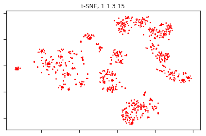

```python
def make_plot(plot_data, name):
    '''
    '''
    plt.scatter(plot_data[:,0], plot_data[:,1], s=2, color='red')
    plt.title(name)
    plt.gca().get_xaxis().set_ticklabels([])
    plt.gca().get_yaxis().set_ticklabels([])
    plt.tight_layout()


X = PCA(n_components=50).fit_transform(unirep_data)

# scale the pca to use as initialization
PCAinit = X[:,:2] / np.std(X[:,0]) * 0.0001

# calculate tsne using pca initialization
my_plot = fast_tsne(unirep_data, initialization=PCAinit)


display(make_plot(my_plot, 't-SNE, 1.1.3.15'))
```

```python
def highlight_part_of_plot(plot_data, selected_data, background_data):
    '''
    Plot a single ec number
    '''

    plt.scatter(plot_data[:,0][background_data], plot_data[:,1][background_data], s=7, color=[0.8, 0.8, 0.8])
    plt.scatter(plot_data[:,0][selected_data], plot_data[:,1][selected_data], s=7, color='red')
    plt.title('t-SNE')
    plt.gca().get_xaxis().set_ticklabels([])
    plt.gca().get_yaxis().set_ticklabels([])
    plt.tight_layout()


def highlight_by_color(plot_data, colors):
    '''
    Color t-sne plot by categorical values
    '''
    plt.scatter(plot_data[:,0], plot_data[:,1], s=7, color=colors)

    plt.title('t-SNE')
    plt.gca().get_xaxis().set_ticklabels([])
    plt.gca().get_yaxis().set_ticklabels([])
    plt.legend()
    plt.tight_layout()


def get_colors_for_items(item_list):
    '''
    Get a set of unique colors
    '''
    item_set = sorted(list(set(item_list)))

    colors = scales.rainbow(len(item_set))

    return {k:v for k,v in zip(list(item_set), colors)}



def make_ordered_color_list(input_list, input_dict):
    '''
    Make a list of colors that signify some information in the fasta header
    '''
    data = []
    for thing in input_list:

        data.append(str(input_dict[thing]))

    return np.array(data)
```

#### Color t-SNE by clusters to validate that it is good

```
No handles with labels found to put in legend.
```

```
None
```

```
array(['#ff8f2f', '#ff8f2f', '#adff2f', ..., '#ff8f2f', '#ff8f2f',
       '#fff02f'], dtype='<U7')
```

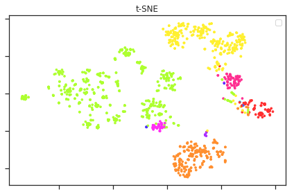

```python
# get a list of all clusters
items_list = unirep_subset.cluster.values

# get colors
items_dict = get_colors_for_items(items_list)
color_list = make_ordered_color_list(items_list, items_dict)

# plot it
display(highlight_by_color(my_plot, color_list))


set(items_list)
color_list
```

#### Test different t-SNE settings

```
CPU times: user 2.86 s, sys: 2.1 s, total: 4.96 s
Wall time: 8min 59s
```

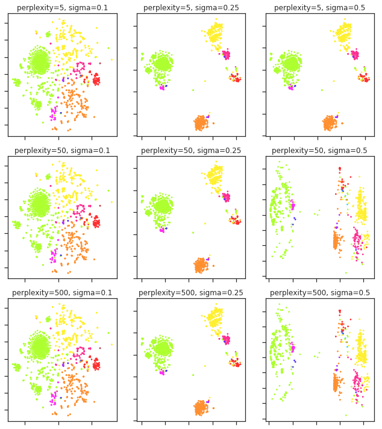

```python
%%time

k = 1000
seed = 42
#iterations = 1000
#noprog = 300
#rate = 200



tsne5_01   = fast_tsne(unirep_data, perplexity=5, sigma=0.1,
                       K=k, seed=seed, initialization=PCAinit)
tsne5_025   = fast_tsne(unirep_data, perplexity=5, sigma=0.25,
                        K=k, seed=seed, initialization=PCAinit)
tsne5_05   = fast_tsne(unirep_data, perplexity=5, sigma=0.5,
                       K=k, seed=seed, initialization=PCAinit)

tsne50_01  = fast_tsne(unirep_data, perplexity=50,  sigma=0.1,
                       K=k, seed=seed, initialization=PCAinit)
tsne50_025  = fast_tsne(unirep_data, perplexity=50,  sigma=0.25,
                        K=k, seed=seed, initialization=PCAinit)
tsne50_05  = fast_tsne(unirep_data, perplexity=50,  sigma=0.5,
                       K=k, seed=seed, initialization=PCAinit)

tsne500_01 = fast_tsne(unirep_data, perplexity=500, sigma=0.1,
                       K=k, seed=seed, initialization=PCAinit)
tsne500_025 = fast_tsne(unirep_data, perplexity=500, sigma=0.25,
                        K=k, seed=seed, initialization=PCAinit)
tsne500_05 = fast_tsne(unirep_data, perplexity=500, sigma=0.5,
                       K=k, seed=seed, initialization=PCAinit)

tsnes  = [tsne5_01, tsne5_025, tsne5_025, tsne50_01, tsne50_025, tsne50_05, tsne500_01, tsne500_025, tsne500_05]
titles = [(5, 0.1), (5, 0.25), (5, 0.5), (50, 0.1), (50, 0.25), (50, 0.5), (500, 0.1), (500, 0.25), (500, 0.5)]

plt.figure(figsize=(9,10))
for i,t in enumerate(tsnes):
    plt.subplot(3,3,i+1)
    plt.scatter(tsnes[i][:,0], tsnes[i][:,1], s=3, color=color_list)
    plt.title('perplexity=%s, sigma=%s' % (titles[i]))
    plt.gca().get_xaxis().set_ticklabels([])
    plt.gca().get_yaxis().set_ticklabels([])
plt.tight_layout()
```

```python
k = 1000
seed = 42
perplexity = 50
sigma = 0.1
rate = 400
```

I like the setting with: k = 1000, perplexity = 50, sigma = 0.1, Let's try to refine that a little more.

```
CPU times: user 1.11 s, sys: 876 ms, total: 1.99 s
Wall time: 57min 47s
```

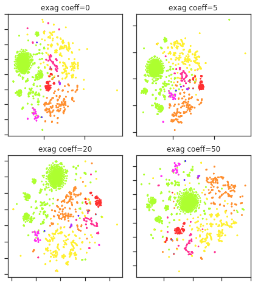

```python
%%time




tsne5_0    = fast_tsne(unirep_data, perplexity=perplexity, sigma=sigma,
                       K=k, seed=seed, initialization=PCAinit, learning_rate=rate,
                        early_exag_coeff=0, stop_early_exag_iter=250, max_iter=2000)

tsne5_5    = fast_tsne(unirep_data, perplexity=perplexity, sigma=sigma,
                        K=k, seed=seed, initialization=PCAinit, learning_rate=rate,
                      early_exag_coeff=5, stop_early_exag_iter=250, max_iter=2000)

tsne5_20   = fast_tsne(unirep_data, perplexity=perplexity, sigma=sigma,
                       K=k, seed=seed, initialization=PCAinit, learning_rate=rate,
                      early_exag_coeff=20, stop_early_exag_iter=250, max_iter=2000)

tsne5_50   = fast_tsne(unirep_data, perplexity=perplexity, sigma=sigma,
                       K=k, seed=seed, initialization=PCAinit, learning_rate=rate,
                      early_exag_coeff=50, stop_early_exag_iter=250, max_iter=2000)

tsnes  = [tsne5_0, tsne5_5, tsne5_20, tsne5_50]
titles = [(0), (5), (20), (50)]

plt.figure(figsize=(6,6.6))
for i,t in enumerate(tsnes):
    plt.subplot(2,2,i+1)
    plt.scatter(tsnes[i][:,0], tsnes[i][:,1], s=3, color=color_list)
    plt.title('exag coeff=%s' % (titles[i]))
    plt.gca().get_xaxis().set_ticklabels([])
    plt.gca().get_yaxis().set_ticklabels([])
plt.tight_layout()
```

So the final setting that I use is: k = 1000, perplexity = 50, sigma = 0.1, learning_rate = 400, early_exag_coeff = 50, stop_early_exag_iter = 250, max_iter = 2000.

#### Also test UMAP and MDS

```
[]
```

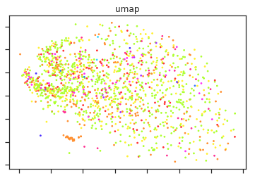

```python
from umap import UMAP

umap = UMAP(n_components=2).fit_transform(unirep_data)


plt.scatter(umap[:,0], umap[:,1], s=3, color=color_list)
plt.title('umap')
plt.gca().get_xaxis().set_ticklabels([])
plt.gca().get_yaxis().set_ticklabels([])
```

This umap plot looks terrible, let's not use.

```
[]
```

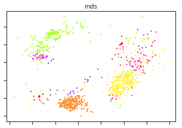

```python
from sklearn.manifold import MDS


mds = MDS(n_components=2, random_state=42).fit_transform(unirep_data)

plt.scatter(mds[:,0], mds[:,1], s=3, color=color_list)
plt.title('mds')
plt.gca().get_xaxis().set_ticklabels([])
plt.gca().get_yaxis().set_ticklabels([])
```